# Employee Attrition Analysis

Tazeb

11/15/2019

## Introduction

Attrition in human resource is the gradual loss of employee over time. It has a problem that impacts all business, irrespective of geography, industry and size of the company. Changes in management style, company structure, or other aspects of the company might cause employees to leave the company voluntarily, resulting in a higher attrition rate. Another possible cause of attrition is when a company eliminates a job completely. This case studuy try to address issues concerning the attrition of an employee with respect to several paramters. The project investigate how the general parameters like Education, Department, Monthly Income, monthlyIncome, OverTime and others impact the attrition of an employee.

## Objectivies

The main goal of the analysis is to study the indicators of attrition in order to identify ways that the company can improve employee retention to save money and time spent in hiring and training.

```r
# load raw data
dataset <- read.csv('CaseStudy2-data.csv', header=TRUE)
```

```r
skim(dataset)
```

Data summary

| Name | dataset |
| --- | --- |
| Number of rows | 870 |
| Number of columns | 36 |
| _______________________ |  |
| Column type frequency: |  |
| factor | 9 |
| numeric | 27 |
| ________________________ |  |
| Group variables | None |

**Variable type: factor**

| skim_variable | n_missing | complete_rate | ordered | n_unique | top_counts |
| --- | --- | --- | --- | --- | --- |
| Attrition | 0 | 1 | FALSE | 2 | No: 730, Yes: 140 |
| BusinessTravel | 0 | 1 | FALSE | 3 | Tra: 618, Tra: 158, Non: 94 |
| Department | 0 | 1 | FALSE | 3 | Res: 562, Sal: 273, Hum: 35 |
| EducationField | 0 | 1 | FALSE | 6 | Lif: 358, Med: 270, Mar: 100, Tec: 75 |
| Gender | 0 | 1 | FALSE | 2 | Mal: 516, Fem: 354 |
| JobRole | 0 | 1 | FALSE | 9 | Sal: 200, Res: 172, Lab: 153, Man: 87 |
| MaritalStatus | 0 | 1 | FALSE | 3 | Mar: 410, Sin: 269, Div: 191 |
| Over18 | 0 | 1 | FALSE | 1 | Y: 870 |
| OverTime | 0 | 1 | FALSE | 2 | No: 618, Yes: 252 |

**Variable type: numeric**

| skim_variable | n_missing | complete_rate | mean | sd | p0 | p25 | p50 | p75 | p100 | hist |
| --- | --- | --- | --- | --- | --- | --- | --- | --- | --- | --- |
| ID | 0 | 1 | 435.50 | 251.29 | 1 | 218 | 436 | 653 | 870 | ▇▇▇▇▇ |
| Age | 0 | 1 | 36.83 | 8.93 | 18 | 30 | 35 | 43 | 60 | ▂▇▇▃▂ |
| DailyRate | 0 | 1 | 815.23 | 401.12 | 103 | 472 | 818 | 1166 | 1499 | ▇▇▇▇▇ |
| DistanceFromHome | 0 | 1 | 9.34 | 8.14 | 1 | 2 | 7 | 14 | 29 | ▇▅▂▂▂ |
| Education | 0 | 1 | 2.90 | 1.02 | 1 | 2 | 3 | 4 | 5 | ▂▅▇▆▁ |
| EmployeeCount | 0 | 1 | 1.00 | 0.00 | 1 | 1 | 1 | 1 | 1 | ▁▁▇▁▁ |
| EmployeeNumber | 0 | 1 | 1029.83 | 604.79 | 1 | 477 | 1039 | 1562 | 2064 | ▇▇▇▇▇ |
| EnvironmentSatisfaction | 0 | 1 | 2.70 | 1.10 | 1 | 2 | 3 | 4 | 4 | ▅▆▁▇▇ |
| HourlyRate | 0 | 1 | 65.61 | 20.13 | 30 | 48 | 66 | 83 | 100 | ▇▇▆▇▇ |
| JobInvolvement | 0 | 1 | 2.72 | 0.70 | 1 | 2 | 3 | 3 | 4 | ▁▃▁▇▁ |
| JobLevel | 0 | 1 | 2.04 | 1.09 | 1 | 1 | 2 | 3 | 5 | ▇▇▃▂▁ |
| JobSatisfaction | 0 | 1 | 2.71 | 1.11 | 1 | 2 | 3 | 4 | 4 | ▅▅▁▇▇ |
| MonthlyIncome | 0 | 1 | 6390.26 | 4597.70 | 1081 | 2840 | 4946 | 8182 | 19999 | ▇▅▂▁▁ |
| MonthlyRate | 0 | 1 | 14325.62 | 7108.38 | 2094 | 8092 | 14074 | 20456 | 26997 | ▇▇▇▇▇ |
| NumCompaniesWorked | 0 | 1 | 2.73 | 2.52 | 0 | 1 | 2 | 4 | 9 | ▇▃▂▂▁ |
| PercentSalaryHike | 0 | 1 | 15.20 | 3.68 | 11 | 12 | 14 | 18 | 25 | ▇▅▃▂▁ |
| PerformanceRating | 0 | 1 | 3.15 | 0.36 | 3 | 3 | 3 | 3 | 4 | ▇▁▁▁▂ |
| RelationshipSatisfaction | 0 | 1 | 2.71 | 1.10 | 1 | 2 | 3 | 4 | 4 | ▅▅▁▇▇ |
| StandardHours | 0 | 1 | 80.00 | 0.00 | 80 | 80 | 80 | 80 | 80 | ▁▁▇▁▁ |
| StockOptionLevel | 0 | 1 | 0.78 | 0.86 | 0 | 0 | 1 | 1 | 3 | ▇▇▁▂▁ |
| TotalWorkingYears | 0 | 1 | 11.05 | 7.51 | 0 | 6 | 10 | 15 | 40 | ▇▇▂▁▁ |
| TrainingTimesLastYear | 0 | 1 | 2.83 | 1.27 | 0 | 2 | 3 | 3 | 6 | ▂▇▇▂▃ |
| WorkLifeBalance | 0 | 1 | 2.78 | 0.71 | 1 | 2 | 3 | 3 | 4 | ▁▃▁▇▂ |
| YearsAtCompany | 0 | 1 | 6.96 | 6.02 | 0 | 3 | 5 | 10 | 40 | ▇▃▁▁▁ |
| YearsInCurrentRole | 0 | 1 | 4.20 | 3.64 | 0 | 2 | 3 | 7 | 18 | ▇▃▂▁▁ |
| YearsSinceLastPromotion | 0 | 1 | 2.17 | 3.19 | 0 | 0 | 1 | 3 | 15 | ▇▁▁▁▁ |
| YearsWithCurrManager | 0 | 1 | 4.14 | 3.57 | 0 | 2 | 3 | 7 | 17 | ▇▂▅▁▁ |

### Data Cleanup and Conversion

#### Checking for missing data values

```r
employee = dataset
```

```r
# look for and drop columns with no variation
drop_columns <- which(apply(employee, 2, function(x) (length(unique(x)) == 1)))
cols <- names(drop_columns)
employee <- employee[,-drop_columns]
# find columns of class factor
factor_columns <- names(which(sapply(names(employee),function(x) class(employee[[x]])=="factor")))
# convert factors to numeric
#employee$Attrition <- as.numeric(employee$Attrition)-1
employee$DailyRate <- NULL
employee$EmployeeNumber <- NULL
employee$MonthlyRate <- NULL
employee$HourlyRate <- NULL
```

```r
# check for missing data values
numNAs <- sum(apply(employee,2,is.na))
```

```r
dim(employee)
```

```
## [1] 870  29
```

```r
names(employee)
```

```
##  [1] "ID"                       "Age"
##  [3] "Attrition"                "BusinessTravel"
##  [5] "Department"               "DistanceFromHome"
##  [7] "Education"                "EducationField"
##  [9] "EnvironmentSatisfaction"  "Gender"
## [11] "JobInvolvement"           "JobLevel"
## [13] "JobRole"                  "JobSatisfaction"
## [15] "MaritalStatus"            "MonthlyIncome"
## [17] "NumCompaniesWorked"       "OverTime"
## [19] "PercentSalaryHike"        "PerformanceRating"
## [21] "RelationshipSatisfaction" "StockOptionLevel"
## [23] "TotalWorkingYears"        "TrainingTimesLastYear"
## [25] "WorkLifeBalance"          "YearsAtCompany"
## [27] "YearsInCurrentRole"       "YearsSinceLastPromotion"
## [29] "YearsWithCurrManager"
```

```r
DT::datatable(employee[1:100,])
```

|  | ID | Age | Attrition | BusinessTravel | Department | DistanceFromHome | Education | EducationField | EnvironmentSatisfaction | Gender | JobInvolvement | JobLevel | JobRole | JobSatisfaction | MaritalStatus | MonthlyIncome | NumCompaniesWorked | OverTime | PercentSalaryHike | PerformanceRating | RelationshipSatisfaction | StockOptionLevel | TotalWorkingYears | TrainingTimesLastYear | WorkLifeBalance | YearsAtCompany | YearsInCurrentRole | YearsSinceLastPromotion | YearsWithCurrManager |
| --- | --- | --- | --- | --- | --- | --- | --- | --- | --- | --- | --- | --- | --- | --- | --- | --- | --- | --- | --- | --- | --- | --- | --- | --- | --- | --- | --- | --- | --- |
| 1 | 1 | 32 | No | Travel_Rarely | Sales | 13 | 4 | Life Sciences | 2 | Male | 3 | 2 | Sales Executive | 4 | Divorced | 4403 | 2 | No | 11 | 3 | 3 | 1 | 8 | 3 | 2 | 5 | 2 | 0 | 3 |
| 2 | 2 | 40 | No | Travel_Rarely | Research &amp; Development | 14 | 3 | Medical | 3 | Male | 2 | 5 | Research Director | 3 | Single | 19626 | 1 | No | 14 | 3 | 1 | 0 | 21 | 2 | 4 | 20 | 7 | 4 | 9 |
| 3 | 3 | 35 | No | Travel_Frequently | Research &amp; Development | 18 | 2 | Life Sciences | 3 | Male | 3 | 3 | Manufacturing Director | 4 | Single | 9362 | 2 | No | 11 | 3 | 3 | 0 | 10 | 2 | 3 | 2 | 2 | 2 | 2 |
| 4 | 4 | 32 | No | Travel_Rarely | Sales | 1 | 4 | Marketing | 3 | Female | 3 | 3 | Sales Executive | 4 | Married | 10422 | 1 | No | 19 | 3 | 3 | 2 | 14 | 3 | 3 | 14 | 10 | 5 | 7 |
| 5 | 5 | 24 | No | Travel_Frequently | Research &amp; Development | 2 | 1 | Technical Degree | 1 | Female | 3 | 1 | Research Scientist | 4 | Single | 3760 | 1 | Yes | 13 | 3 | 3 | 0 | 6 | 2 | 3 | 6 | 3 | 1 | 3 |
| 6 | 6 | 27 | No | Travel_Frequently | Research &amp; Development | 10 | 2 | Life Sciences | 4 | Male | 3 | 3 | Manufacturing Director | 1 | Divorced | 8793 | 1 | No | 21 | 4 | 3 | 2 | 9 | 4 | 2 | 9 | 7 | 1 | 7 |
| 7 | 7 | 41 | No | Travel_Rarely | Research &amp; Development | 5 | 5 | Medical | 2 | Male | 4 | 1 | Research Scientist | 3 | Married | 2127 | 2 | Yes | 12 | 3 | 1 | 0 | 7 | 5 | 2 | 4 | 2 | 0 | 3 |
| 8 | 8 | 37 | No | Travel_Rarely | Sales | 10 | 4 | Life Sciences | 4 | Female | 2 | 2 | Sales Executive | 4 | Divorced | 6694 | 2 | Yes | 14 | 3 | 3 | 3 | 8 | 5 | 3 | 1 | 0 | 0 | 0 |
| 9 | 9 | 34 | No | Travel_Rarely | Sales | 10 | 4 | Life Sciences | 3 | Female | 3 | 1 | Sales Representative | 3 | Married | 2220 | 1 | Yes | 19 | 3 | 4 | 1 | 1 | 2 | 3 | 1 | 1 | 0 | 0 |
| 10 | 10 | 34 | No | Travel_Frequently | Research &amp; Development | 10 | 4 | Technical Degree | 4 | Male | 2 | 2 | Healthcare Representative | 3 | Married | 5063 | 1 | No | 14 | 3 | 2 | 1 | 8 | 3 | 2 | 8 | 2 | 7 | 7 |

[output cut: 90 more lines]

Looking the data type; it helps to manage and convert the data

```r
str(employee)
```

```
## 'data.frame':    870 obs. of  29 variables:
##  $ ID                      : int  1 2 3 4 5 6 7 8 9 10 ...
##  $ Age                     : int  32 40 35 32 24 27 41 37 34 34 ...
##  $ Attrition               : Factor w/ 2 levels "No","Yes": 1 1 1 1 1 1 1 1 1 1 ...
##  $ BusinessTravel          : Factor w/ 3 levels "Non-Travel","Travel_Frequently",..: 3 3 2 3 2 2 3 3 3 2 ...
##  $ Department              : Factor w/ 3 levels "Human Resources",..: 3 2 2 3 2 2 2 3 3 2 ...
##  $ DistanceFromHome        : int  13 14 18 1 2 10 5 10 10 10 ...
##  $ Education               : int  4 3 2 4 1 2 5 4 4 4 ...
##  $ EducationField          : Factor w/ 6 levels "Human Resources",..: 2 4 2 3 6 2 4 2 2 6 ...
##  $ EnvironmentSatisfaction : int  2 3 3 3 1 4 2 4 3 4 ...
##  $ Gender                  : Factor w/ 2 levels "Female","Male": 2 2 2 1 1 2 2 1 1 2 ...
##  $ JobInvolvement          : int  3 2 3 3 3 3 4 2 3 2 ...
##  $ JobLevel                : int  2 5 3 3 1 3 1 2 1 2 ...
##  $ JobRole                 : Factor w/ 9 levels "Healthcare Representative",..: 8 6 5 8 7 5 7 8 9 1 ...
##  $ JobSatisfaction         : int  4 3 4 4 4 1 3 4 3 3 ...
##  $ MaritalStatus           : Factor w/ 3 levels "Divorced","Married",..: 1 3 3 2 3 1 2 1 2 2 ...
##  $ MonthlyIncome           : int  4403 19626 9362 10422 3760 8793 2127 6694 2220 5063 ...
##  $ NumCompaniesWorked      : int  2 1 2 1 1 1 2 2 1 1 ...
##  $ OverTime                : Factor w/ 2 levels "No","Yes": 1 1 1 1 2 1 2 2 2 1 ...
##  $ PercentSalaryHike       : int  11 14 11 19 13 21 12 14 19 14 ...
##  $ PerformanceRating       : int  3 3 3 3 3 4 3 3 3 3 ...
##  $ RelationshipSatisfaction: int  3 1 3 3 3 3 1 3 4 2 ...
##  $ StockOptionLevel        : int  1 0 0 2 0 2 0 3 1 1 ...
##  $ TotalWorkingYears       : int  8 21 10 14 6 9 7 8 1 8 ...
##  $ TrainingTimesLastYear   : int  3 2 2 3 2 4 5 5 2 3 ...
##  $ WorkLifeBalance         : int  2 4 3 3 3 2 2 3 3 2 ...
##  $ YearsAtCompany          : int  5 20 2 14 6 9 4 1 1 8 ...
##  $ YearsInCurrentRole      : int  2 7 2 10 3 7 2 0 1 2 ...
##  $ YearsSinceLastPromotion : int  0 4 2 5 1 1 0 0 0 7 ...
##  $ YearsWithCurrManager    : int  3 9 2 7 3 7 3 0 0 7 ...
```

Let us start by taking a look at the attrition percentage.

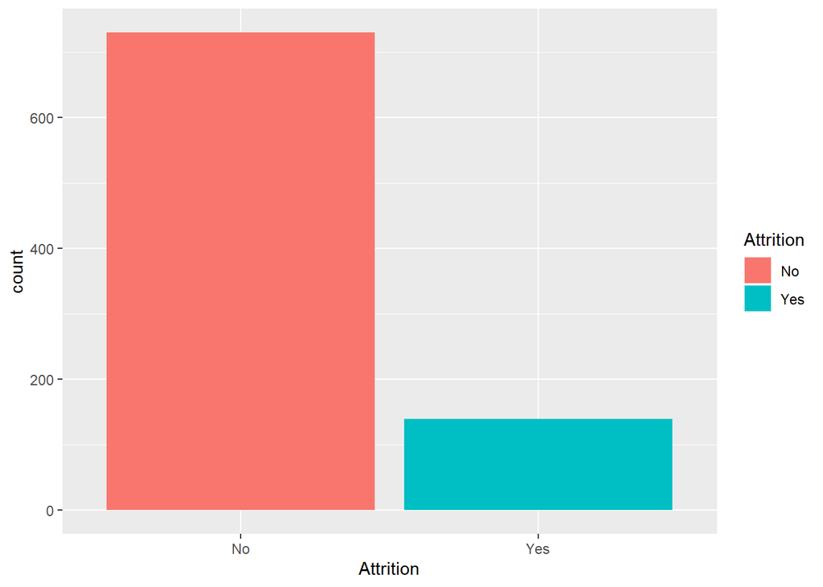

```r
ggplot(employee,aes(Attrition,fill=Attrition))+geom_bar()
```

Histograms

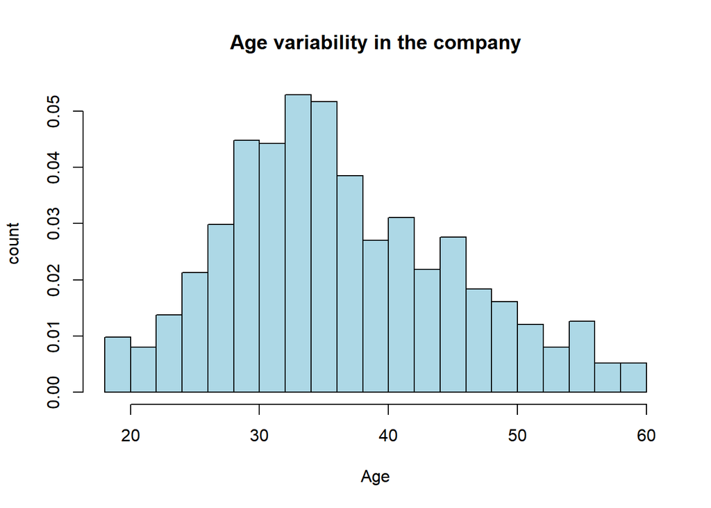

```r
hist(employee$Age,xlab="Age",ylab="count",breaks=20,main="Age variability in the company",col="lightblue",freq=FALSE)
```

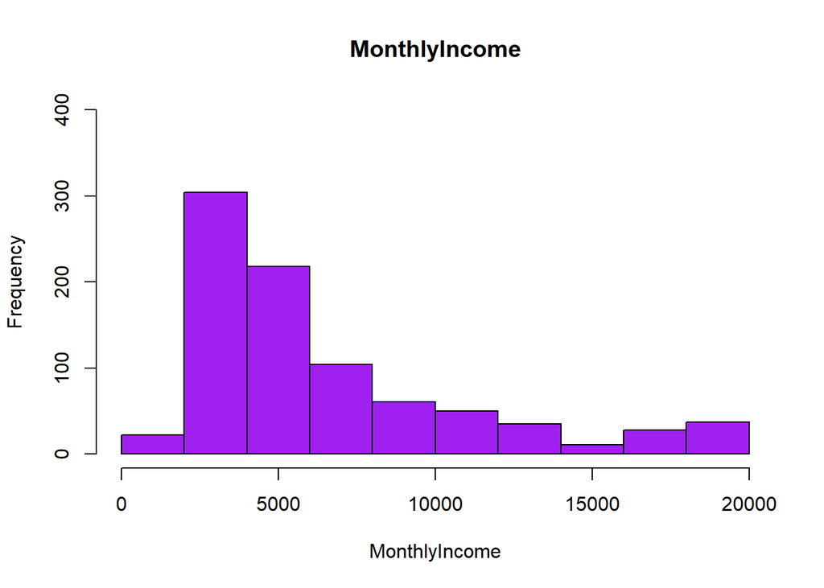

```r
# Histogram with normal curve for monthly income
hist(employee$MonthlyIncome,xlab="MonthlyIncome",ylab="Frequency",breaks=10,main="MonthlyIncome",col="purple",ylim=c(0,400))
```

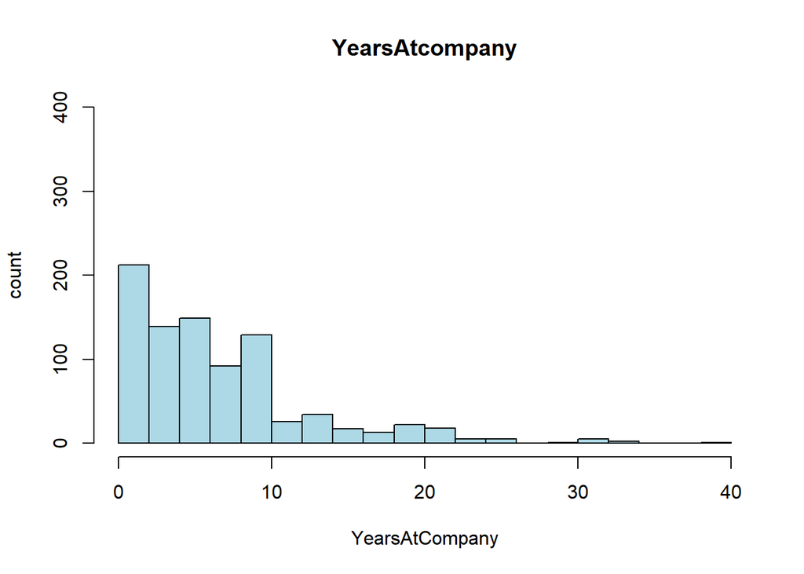

```r
hist(employee$YearsAtCompany,xlab="YearsAtCompany",ylab="count",breaks=20,main="YearsAtcompany",col="lightblue",ylim=c(0,400))
```

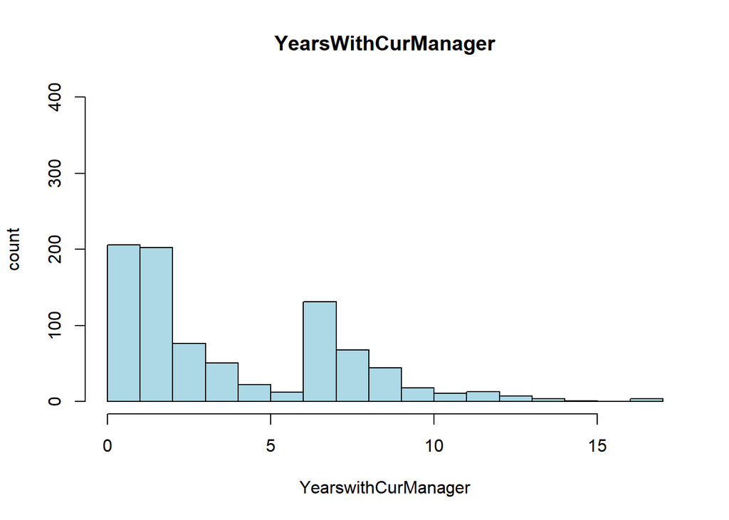

```r
hist(employee$YearsWithCurrManager,xlab="YearswithCurManager",ylab="count",breaks=20,main="YearsWithCurManager",col="lightblue",ylim=c(0,400))
```

```r
# descriptive statistics, load into new data frame for processing
descriptiveTable <- pastecs::stat.desc(employee)
# remove non-numeric features
charCols <- c("Attrition", "BusinessTravel", "Department", "EducationField", "Gender", "JobRole", "MaritalStatus", "OverTime")
continuousTable.stats <- descriptiveTable[,!(colnames(descriptiveTable) %in% charCols)]
categoricalTable <- employee[,(colnames(descriptiveTable) %in% charCols)]
continuousTable <- employee[,!(colnames(employee) %in% charCols)]
# remove rows for certain descriptive statistics leaving: N, Mean, Median, Std Dev, Var, Min, Max
remove <- c("CI.mean.0.95", "nbr.val", "nbr.null", "nbr.na", "range", "sum", "SE.mean", "CI.mean", "coef.var")
continuousTable.stats <- continuousTable.stats[-which(rownames(continuousTable.stats) %in% remove),]
# round all numeric values to 2 decimal points
continuousTable.stats <- round(continuousTable.stats, 2)
continuousTable.transposed <- t(continuousTable.stats) # object becomes matrix

# display descriptive statistics
knitr::kable(continuousTable.transposed,caption = "Descriptive Statistics for Numeric Features in the Raw Employee Data", row.names = TRUE, "html") %>%
  kable_styling(bootstrap_options = c("striped","hover", "condensed", "responsive"), full_width = F)
```

Descriptive Statistics for Numeric Features in the Raw Employee Data

|  | min | max | median | mean | var | std.dev |
| --- | --- | --- | --- | --- | --- | --- |
| ID | 1 | 870 | 436 | 435.50 | 63147.50 | 251.29 |
| Age | 18 | 60 | 35 | 36.83 | 79.67 | 8.93 |
| DistanceFromHome | 1 | 29 | 7 | 9.34 | 66.21 | 8.14 |
| Education | 1 | 5 | 3 | 2.90 | 1.05 | 1.02 |
| EnvironmentSatisfaction | 1 | 4 | 3 | 2.70 | 1.21 | 1.10 |
| JobInvolvement | 1 | 4 | 3 | 2.72 | 0.50 | 0.70 |
| JobLevel | 1 | 5 | 2 | 2.04 | 1.19 | 1.09 |
| JobSatisfaction | 1 | 4 | 3 | 2.71 | 1.24 | 1.11 |
| MonthlyIncome | 1081 | 19999 | 4946 | 6390.26 | 21138808.27 | 4597.70 |
| NumCompaniesWorked | 0 | 9 | 2 | 2.73 | 6.35 | 2.52 |
| PercentSalaryHike | 11 | 25 | 14 | 15.20 | 13.51 | 3.68 |
| PerformanceRating | 3 | 4 | 3 | 3.15 | 0.13 | 0.36 |
| RelationshipSatisfaction | 1 | 4 | 3 | 2.71 | 1.22 | 1.10 |
| StockOptionLevel | 0 | 3 | 1 | 0.78 | 0.74 | 0.86 |
| TotalWorkingYears | 0 | 40 | 10 | 11.05 | 56.46 | 7.51 |
| TrainingTimesLastYear | 0 | 6 | 3 | 2.83 | 1.62 | 1.27 |
| WorkLifeBalance | 1 | 4 | 3 | 2.78 | 0.51 | 0.71 |
| YearsAtCompany | 0 | 40 | 5 | 6.96 | 36.25 | 6.02 |
| YearsInCurrentRole | 0 | 18 | 3 | 4.20 | 13.24 | 3.64 |
| YearsSinceLastPromotion | 0 | 15 | 1 | 2.17 | 10.15 | 3.19 |
| YearsWithCurrManager | 0 | 17 | 3 | 4.14 | 12.78 | 3.57 |

```r
summary(categoricalTable)
```

```
##  Attrition           BusinessTravel                  Department
##  No :730   Non-Travel       : 94    Human Resources       : 35
##  Yes:140   Travel_Frequently:158    Research & Development:562
##            Travel_Rarely    :618    Sales                 :273
##
##
##
##
##           EducationField    Gender                         JobRole
##  Human Resources : 15    Female:354   Sales Executive          :200
##  Life Sciences   :358    Male  :516   Research Scientist       :172
##  Marketing       :100                 Laboratory Technician    :153
##  Medical         :270                 Manufacturing Director   : 87
##  Other           : 52                 Healthcare Representative: 76
##  Technical Degree: 75                 Sales Representative     : 53
##                                       (Other)                  :129
##   MaritalStatus OverTime
##  Divorced:191   No :618
##  Married :410   Yes:252
##  Single  :269
##
##
##
##
```

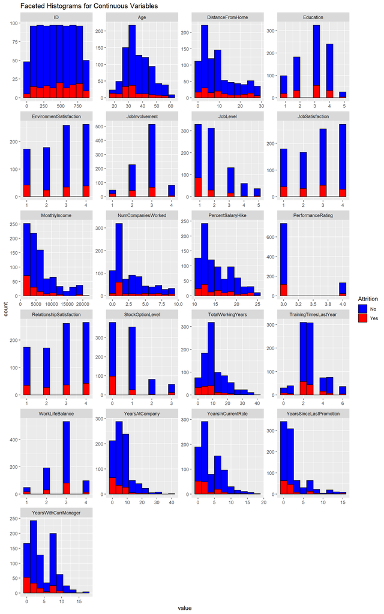

```r
continuousTable$Attrition <- employee$Attrition
continuousTable$EmployeeCount <- NULL
continuousTable$EmployeeNumber <- NULL
continuousTable$StandardHours <- NULL

facetPlot <- melt(continuousTable, id.vars = "Attrition")

p <- ggplot(data = facetPlot, aes(x = value, fill=Attrition)) +
    geom_histogram(bins = 10, colour = "black") +
    facet_wrap(~variable, scales = 'free', ncol = 4) +
    labs(title="Faceted Histograms for Continuous Variables", title_x="", title_y="") +
    scale_fill_manual(values = c("blue","red"))

p
```

```r
# the above ggplot doesn't seem to render correctly in RMarkdown, but it does in R Studio if you're curious. Therefore, we are displaying the result as a static image loaded from GitHub.
```

# Correlation Matrix

```r
employee$Attrition <- as.numeric(employee$Attrition)-1
cor_vars <- data.frame(employee$Attrition,employee$Age, employee$DistanceFromHome,employee$Education, employee$EnvironmentSatisfaction, employee$MonthlyIncome, employee$JobInvolvement , employee$JobLevel,employee$JobSatisfaction,employee$NumCompaniesWorked,employee$PerformanceRating,employee$PerformanceRating,employee$RelationshipSatisfaction,  employee$StockOptionLevel, employee$StockOptionLevel, employee$TotalWorkingYears,employee$TrainingTimesLastYear, employee$WorkLifeBalance, employee$YearsAtCompany, employee$YearsInCurrentRole, employee$YearsSinceLastPromotion, employee$YearsWithCurrManager)



cor(cor_vars)
```

```
##                                   employee.Attrition employee.Age
## employee.Attrition                            1.0000      -0.1494
## employee.Age                                 -0.1494       1.0000
## employee.DistanceFromHome                     0.0871       0.0066
## employee.Education                           -0.0494       0.2173
## employee.EnvironmentSatisfaction             -0.0773      -0.0074
## employee.MonthlyIncome                       -0.1549       0.4843
## employee.JobInvolvement                      -0.1878       0.0161
## employee.JobLevel                            -0.1621       0.4794
## employee.JobSatisfaction                     -0.1075      -0.0224
## employee.NumCompaniesWorked                   0.0610       0.2935
## employee.PerformanceRating                    0.0153      -0.0411
## employee.PerformanceRating.1                  0.0153      -0.0411
## employee.RelationshipSatisfaction            -0.0396      -0.0053
## employee.StockOptionLevel                    -0.1487       0.0448
## employee.StockOptionLevel.1                  -0.1487       0.0448
## employee.TotalWorkingYears                   -0.1672       0.6526
## employee.TrainingTimesLastYear               -0.0627      -0.0453
## employee.WorkLifeBalance                     -0.0898      -0.0122
## employee.YearsAtCompany                      -0.1288       0.2895
## employee.YearsInCurrentRole                  -0.1562       0.2083
## employee.YearsSinceLastPromotion             -0.0046       0.2172
## employee.YearsWithCurrManager                -0.1468       0.1854
##                                   employee.DistanceFromHome
## employee.Attrition                                   0.0871
## employee.Age                                         0.0066
## employee.DistanceFromHome                            1.0000
## employee.Education                                   0.0495
## employee.EnvironmentSatisfaction                    -0.0387
## employee.MonthlyIncome                              -0.0067
## employee.JobInvolvement                             -0.0043
## employee.JobLevel                                    0.0217
## employee.JobSatisfaction                            -0.0212
## employee.NumCompaniesWorked                         -0.0489
## employee.PerformanceRating                           0.0332
## employee.PerformanceRating.1                         0.0332
## employee.RelationshipSatisfaction                    0.0362
## employee.StockOptionLevel                            0.0717
## employee.StockOptionLevel.1                          0.0717
## employee.TotalWorkingYears                           0.0042
```

[output cut: 428 more lines]

```
## employee.JobLevel                                        0.3666
## employee.JobSatisfaction                                 0.0074
## employee.NumCompaniesWorked                             -0.1230
## employee.PerformanceRating                              -0.0049
## employee.PerformanceRating.1                            -0.0049
## employee.RelationshipSatisfaction                       -0.0161
## employee.StockOptionLevel                                0.0365
## employee.StockOptionLevel.1                              0.0365
## employee.TotalWorkingYears                               0.4615
## employee.TrainingTimesLastYear                           0.0039
## employee.WorkLifeBalance                                 0.0184
## employee.YearsAtCompany                                  0.7652
## employee.YearsInCurrentRole                              0.7095
## employee.YearsSinceLastPromotion                         0.5089
## employee.YearsWithCurrManager                            1.0000
```

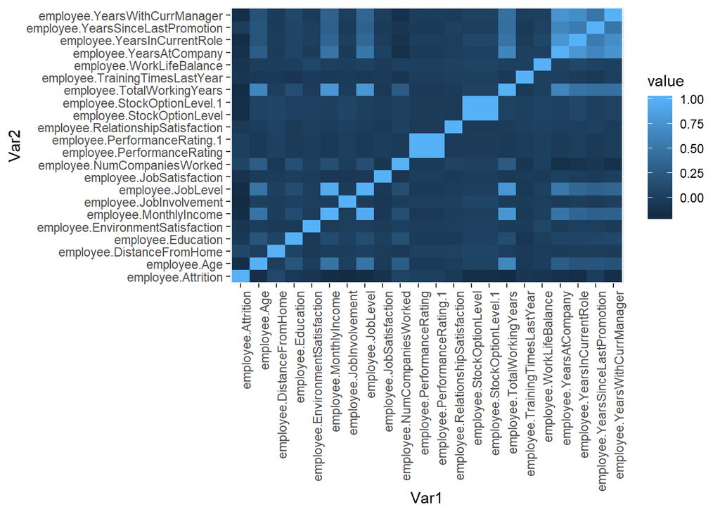

```r
trans<-cor(cor_vars)
melted_cormat <- melt(trans)

 ggplot(data = melted_cormat, aes(x=Var1, y=Var2, fill=value)) +
  geom_tile() +theme(axis.text.x = element_text(angle = 90, hjust = 1))
```

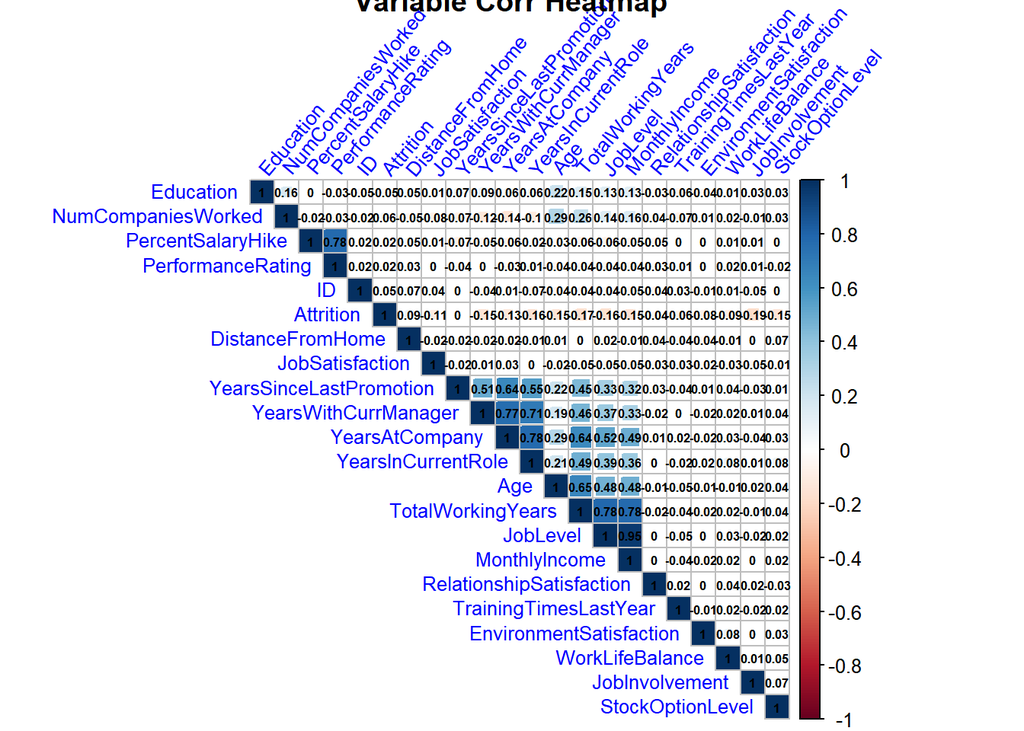

```r
employee %>% keep(is.numeric) %>% na.omit %>% cor %>% corrplot("upper", addCoef.col = "black",tl.col = "blue", number.digits = 2,
             number.cex = 0.5, method="square",
             order="hclust", title="Variable Corr Heatmap",
             tl.srt=50, tl.cex = 0.8)
```

High Correlation Results: having above 70% correlation

- MonthlyIncome vs. JobLevel (95.16% correlation)
- TotalWorkingYears vs. JobLevel (78.08% correlation)
- MonthlyIncome vs. TotalWorkingYears (77.85% correlation)
- YearsAtCompany vs. YearsInCurrentRole (77.61% correlation)
- YearsAtCompany vs. YearsWithCurrManager (76.52% correlation
- YearsWithCurrManager vs. YearsInCurrentRole (70.95% correlation)